# Pre-session 2 Instructions

Translational Data Science Part 1 - S2

For this session you will need to make sure you have the following items installed on your computer/laptop:

- Bash
- Git
- Git-it

We have provided you with instructions below. Please let us know before next week’s session if you experience any difficulties or have any questions.

# Installing Bash on your computer

For Week 3 all of you will need access to the Bash command line. Some of you - those with a Windows operating system - will require it this week. Please go to this webpage https://carpentries.github.io/workshop-template/#shell, select your appropriate operating system and follow the instructions to install Bash on your computer.

Once you are done with this step move onto install Git on your computer.

# Installing Git on your computer

For this week’s session you will need to install Git. The installation process will depend on the type of your operating system. Please scroll to your relevant operating system section below and follow the instructions there.

If you experience any difficulties please contact us before the live sessions next week.

## Windows Users

If you are a **Windows** user you will already have git installed on your computer, if you followed the above section on installing Bash, as this was installed via Git-Bash.

You can test if you have git on your computer by doing the following:

**1.** Open Git-Bash by typing ‘Git-Bash’ in the Windows start menu

**2.** In the Git-Bash terminal type in `git --version`.

The command line will inform you of the version of git you have. This should be version 2.29.0.windows.1 or above.

## Mac or Linux Users

If you are a Mac or a Linux user you will need to install Git. Follow the steps [here](https://carpentries.github.io/workshop-template/#git) to install Git on your computer.

You can test if you were successful by following the steps below:

**1.** Open a command-line terminal on your computer and type in `git --version`.

The command line will inform you of the version of git you have. This should be version 2.23.0 or above.

# Installing Git-it on your computer

Follow the below instructions to install Git-it on your computer.

**1.** Go to https://github.com/jlord/git-it-electron/releases and install the relevant version of Git-it for your operating system.

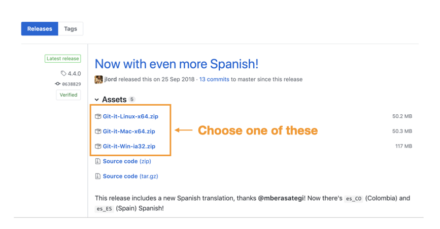

Adapted from [here](https://github.com/jlord/git-it-electron/releases)

**2.** When it downloads, unzip it and double click on the Git-it icon

[figure not shown]

You should then see the following:

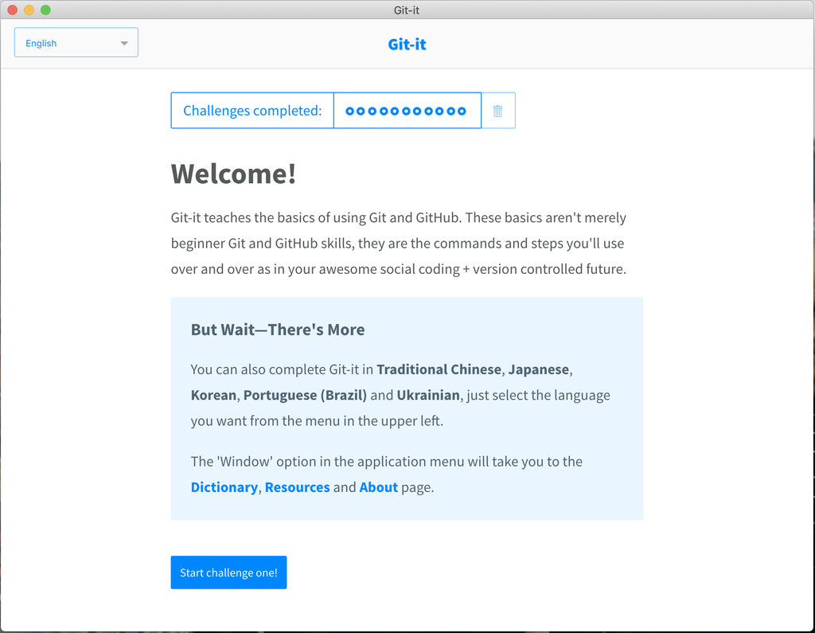

**3.** You don’t need to do the tutorial now. You will work on that in next week. Just make sure it is installed as above.